# HW_Cluster

Игорь Панарин

31 12 2021

Кластерный анализ российских ВУЗов

Данные: https://1drv.ms/x/s!Ao4Ycx5Das5liXyMdyl3BSnrpaci?e=ImHyxd

```r
library(rio)
library(tidyverse)
library(corrplot)
library(Hmisc)
library(dplyr)
library(forcats)
library (ggplot2)
library(skimr)
library(cluster) # кластерный анализ
library(factoextra) # визуализации
library(pvclust) # тоже визуализация
library(NbClust) # визуализации и неиерархический анализ
library(dendextend) # будем раскрашивать дерево
data <- import("/Users/Игорь/Desktop/ВШЭ/Курс 1/Модуль 2/АнДан_Капуза/Кластерный анализ/univer_2017.xlsx")
```

**КЛАСТЕРИЗАЦИЯ**

**Задача 1.** **Кластеризуем ВУЗы по соотношению доход / общая численность научных работников (НР).**

Выберем переменные, стандартизуем, оставим 3 сигма (чтобы выбросы не влияли на результат)

```r
task1 <- select (data, TOTINC, SCIENTIST)
task1$st_TOTINC <- scale(data$TOTINC)
task1$st_SCIENTIST <- scale(data$SCIENTIST)
task1$TOTINC <- NULL
task1$SCIENTIST <-  NULL
task1 <- na.omit(task1)
task1 <- filter(task1, st_TOTINC >-3  & st_TOTINC <3)
task1 <- filter(task1, st_SCIENTIST >-3  & st_SCIENTIST <3)
```

Посмотрим распределения каждой переменной. Распределения - экспоненциальные

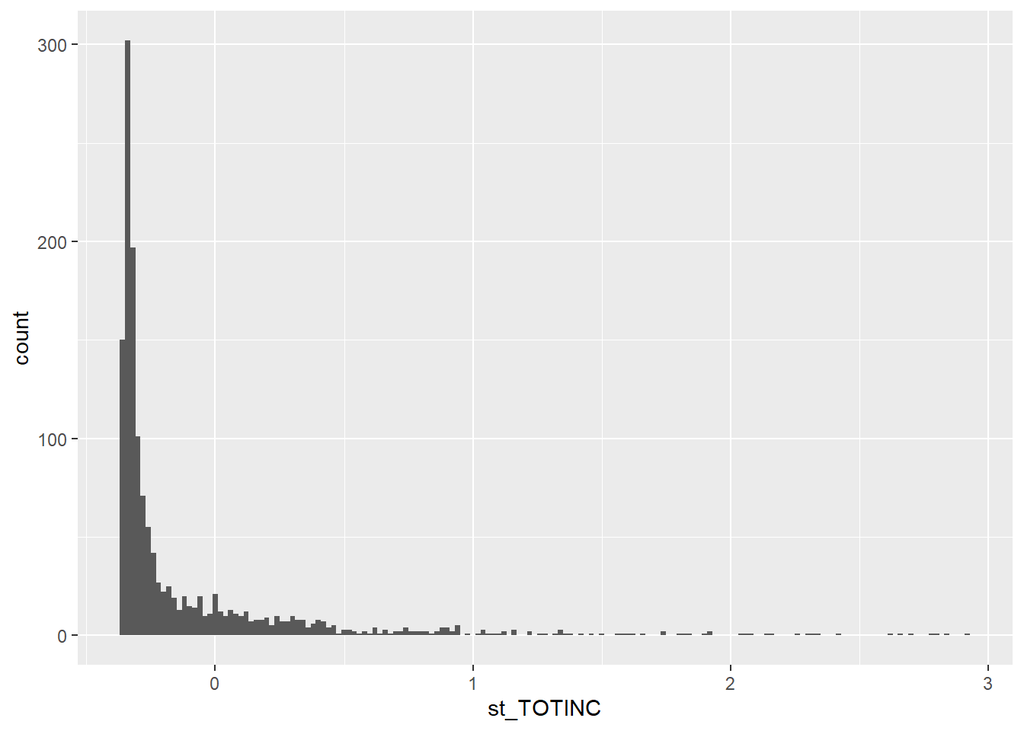

```r
ggplot(task1, aes(x=st_TOTINC)) +
  geom_histogram(binwidth=0.02)
```

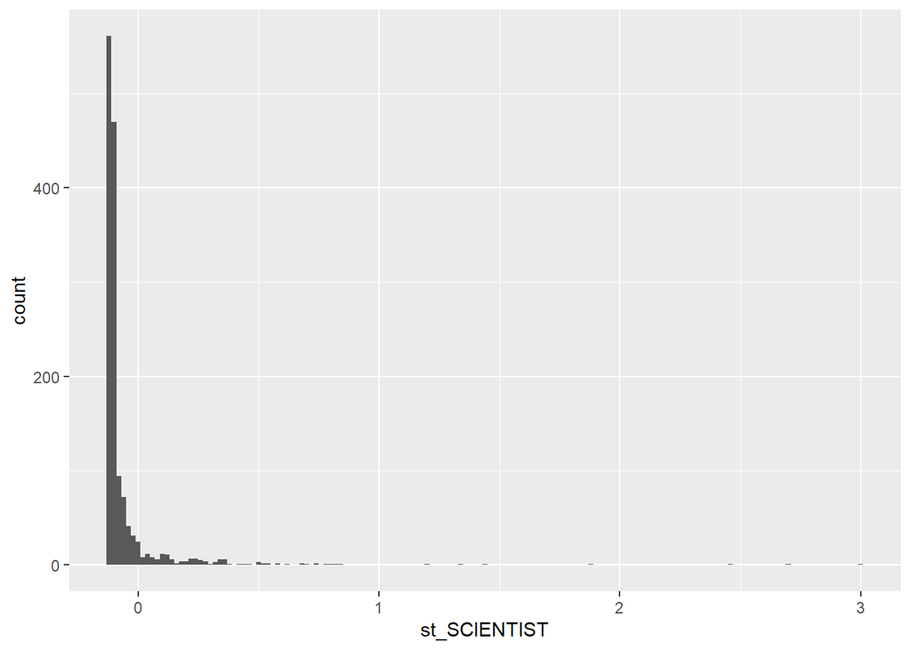

```r
ggplot(task1, aes(x=st_SCIENTIST)) +
  geom_histogram(binwidth=0.02)
```

Посмотрим диаграмму рассеяния:

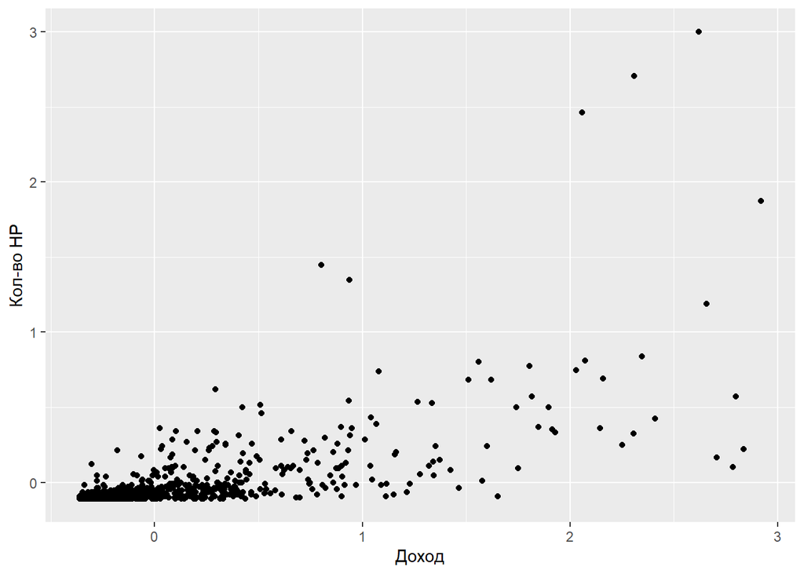

```r
ggplot(task1,
       aes(x=st_TOTINC, y=st_SCIENTIST)) +
  geom_point () +
  xlab("Доход") +
  ylab("Кол-во НР")
```

Визуально можем выделить 3 кластера - основная масса слева внизу, более разреженная область правее и несколько случаев справа сверху. Проведем неиерархический КА (k-means)

Присвоим наблюдениям номера кластеров:

```r
task1$kmeans2 <- cl$cluster
task1 %>% filter(kmeans2 == 1) %>% skim # N=44,   mean доход=1.86 mean НР=0.635
task1 %>% filter(kmeans2 == 2) %>% skim # N=229,  mean доход=0.4 mean НР=0.03
task1 %>% filter(kmeans2 == 3) %>% skim # N=1163, mean доход=-0.275 mean НР=-0.09
```

[output not shown]

Запустим функцию NbClust для определения оптимального числа кластеров:

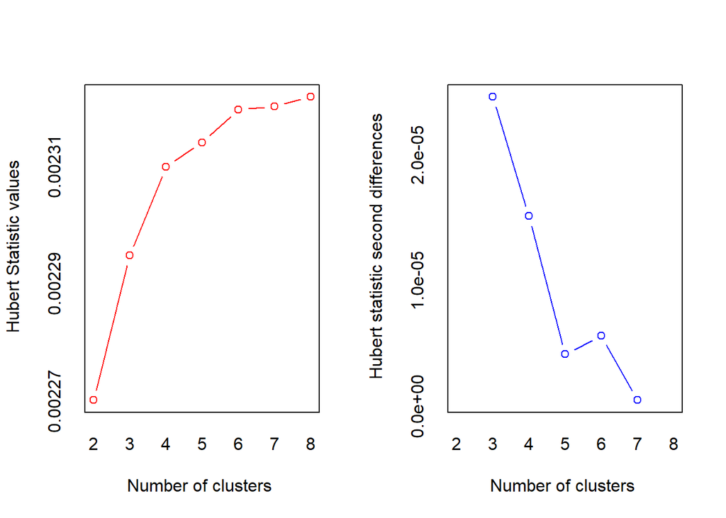

*** : The Hubert index is a graphical method of determining the number of clusters. In the plot of Hubert index, we seek a significant knee that corresponds to a significant increase of the value of the measure i.e the significant peak in Hubert index second differences plot.

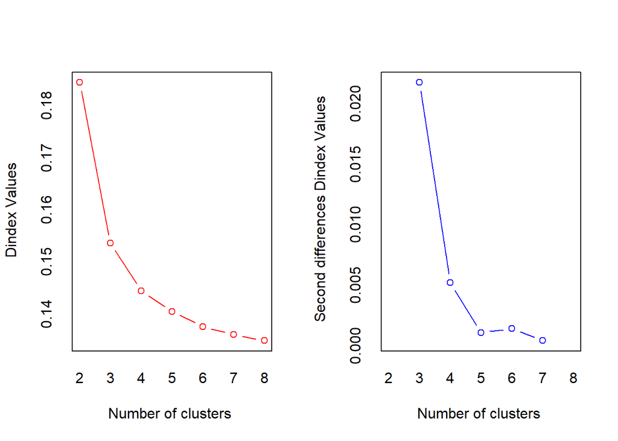

*** : The D index is a graphical method of determining the number of clusters. In the plot of D index, we seek a significant knee (the significant peak in Dindex second differences plot) that corresponds to a significant increase of the value of the measure.

- Among all indices:
- 11 proposed 2 as the best number of clusters
- 12 proposed 3 as the best number of clusters
- 1 proposed 4 as the best number of clusters

  ```
               ***** Conclusion *****
  ```

- According to the majority rule, the best number of clusters is 3

# Among all indices:

- 2 proposed 0 as the best number of clusters
- 11 proposed 2 as the best number of clusters
- 12 proposed 3 as the best number of clusters
- 1 proposed 4 as the best number of clusters

# Conclusion

- According to the majority rule, the best number of clusters is 3 .

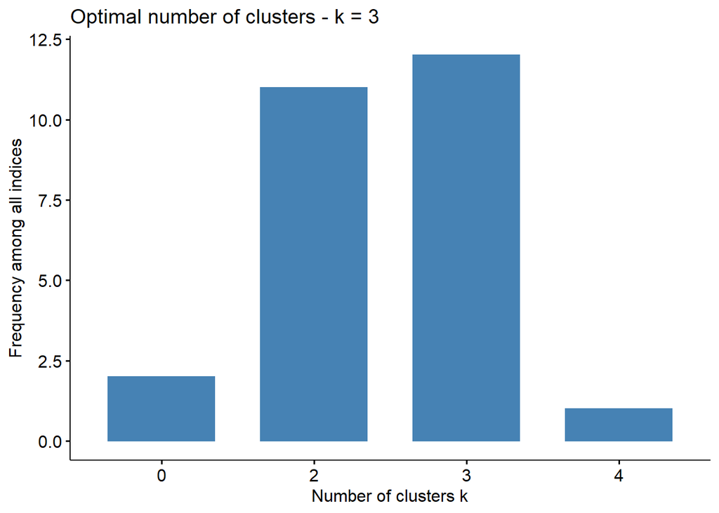

NbClust предлагает 3 кластера.

```r
cl_3 <- kmeans(task1, 3)
task1$kmeans3 <- cl_3$cluster
```

Визуализируем 3 кластера:

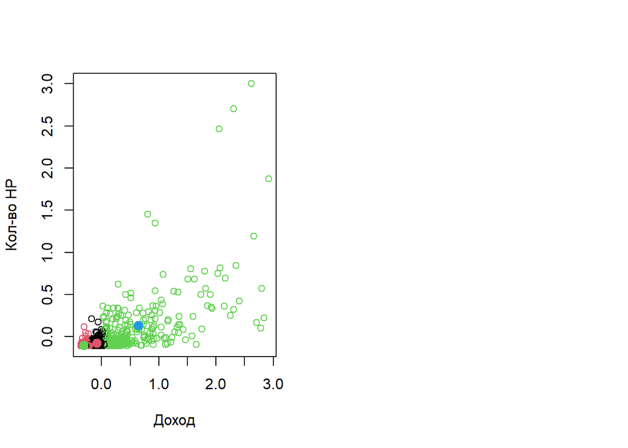

```r
clusterplot <- par(mfrow = c(1, 2))
plot(task1[c("st_TOTINC", "st_SCIENTIST")], col=cl_3$cluster, xlab="Доход", ylab = "Кол-во НР")
points(cl_3$centers[,c("st_TOTINC", "st_SCIENTIST")], col=10:20, pch=20, cex=2)
```

Содержательное описание:

“Средний класс, средний размер” N=229, mean доход=0.4 mean НР=0.03

“Основная масса - скромный доход, небольшие”, N=1163, mean доход=-0.275 mean НР=-0.09

**Задача 2. Кол-во публикаций в WoS / кол-во цитирований в WoS**

Выберем переменные, стандартизуем, оставим 3 сигма (чтобы выбросы не влияли):

```r
task2 <- select (data, WOSPUBL, WOSCIT)
task2$st_WOSPUBL <- scale(data$WOSPUBL)
task2$st_WOSCIT <- scale(data$WOSCIT)
task2$WOSPUBL <- NULL
task2$WOSCIT <-  NULL
task2 <- na.omit(task2)
task2 <- filter(task2, st_WOSPUBL >-3  & st_WOSPUBL <3)
task2 <- filter(task2, st_WOSCIT >-3  & st_WOSCIT <3)
skim(task2$st_WOSCIT)
```

Посмотрим распределения:

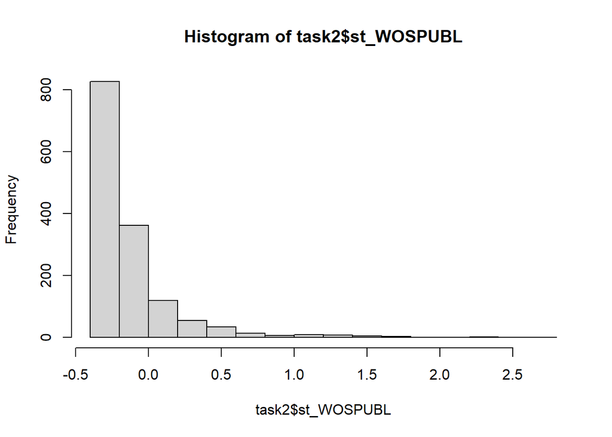

```r
hist(task2$st_WOSPUBL)
```

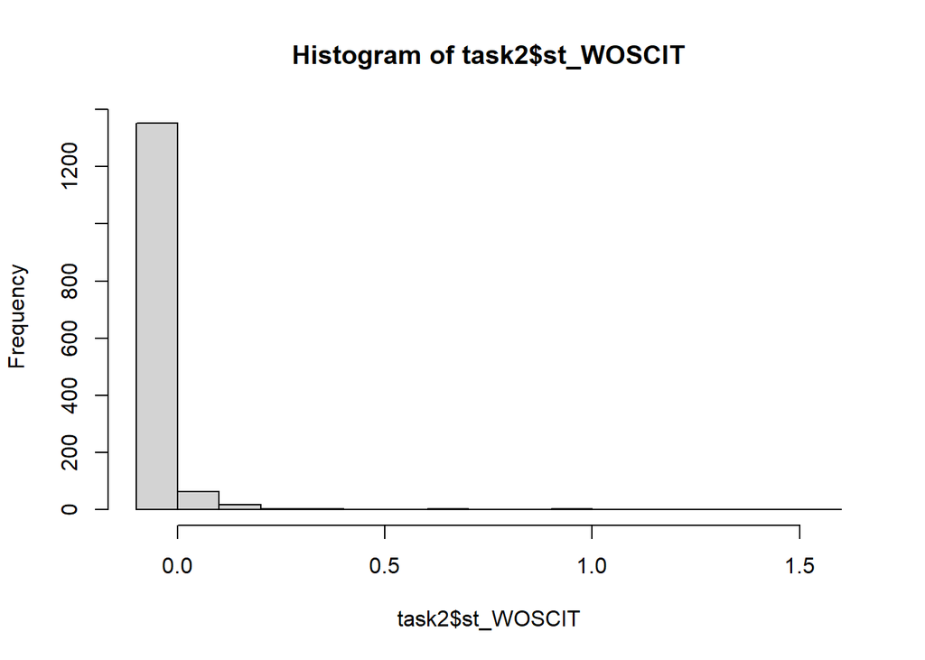

```r
hist(task2$st_WOSCIT)
```

```r
quantile(task2$st_WOSPUBL, .90)
```

```
##       90%
## 0.1851925
```

Посмотрим диаграмму рассеяния:

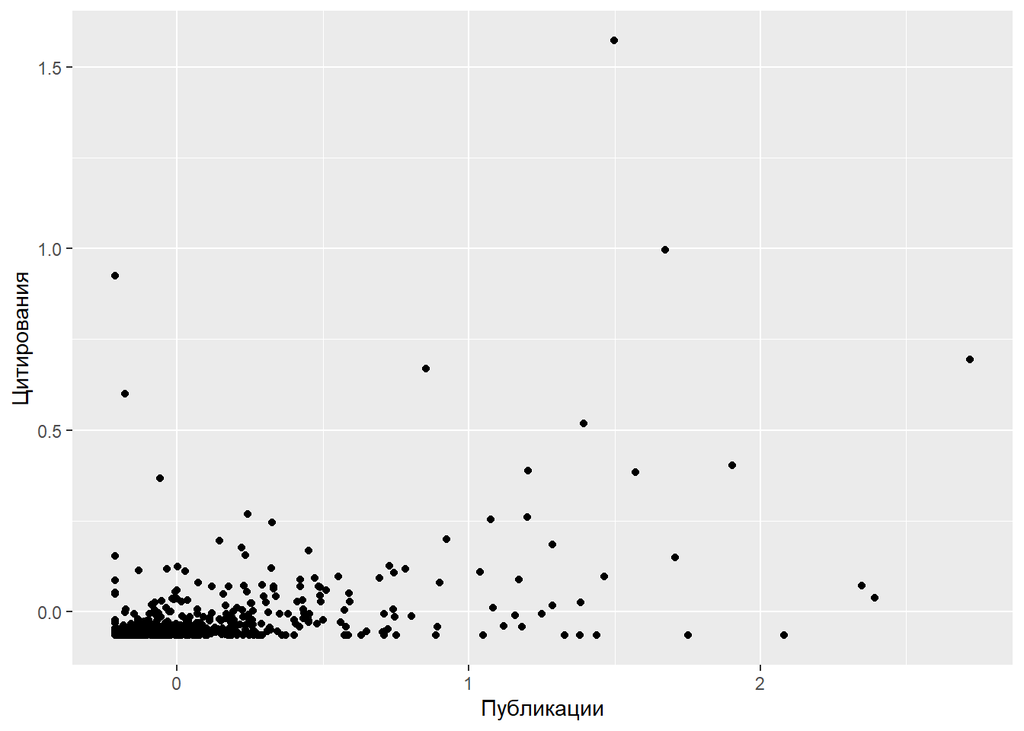

```r
ggplot(task2,
       aes(x=st_WOSPUBL, y=st_WOSCIT)) +
  geom_point () +
  xlab("Публикации") +
  ylab("Цитирования")
```

Визуально выделяются 2 различных по плотности кластера по оси X (Публикации).

Первый кластер ~ до 0.7 сигма, второй - от 0.7 сигма. По количеству цитирований имеются одиночные выбросы, но 99% значений - в пределах 0.25 сигм.

Проверим наше восприятие через иерархический кластерный анализ.

Считаем дистанцию (попробуем метод Manhattan):

```r
md_task2 <- dist(task2,method =  "manhattan")
head(md_task2)
tail(md_task2)
```

Кластерный анализ, метод Wards:

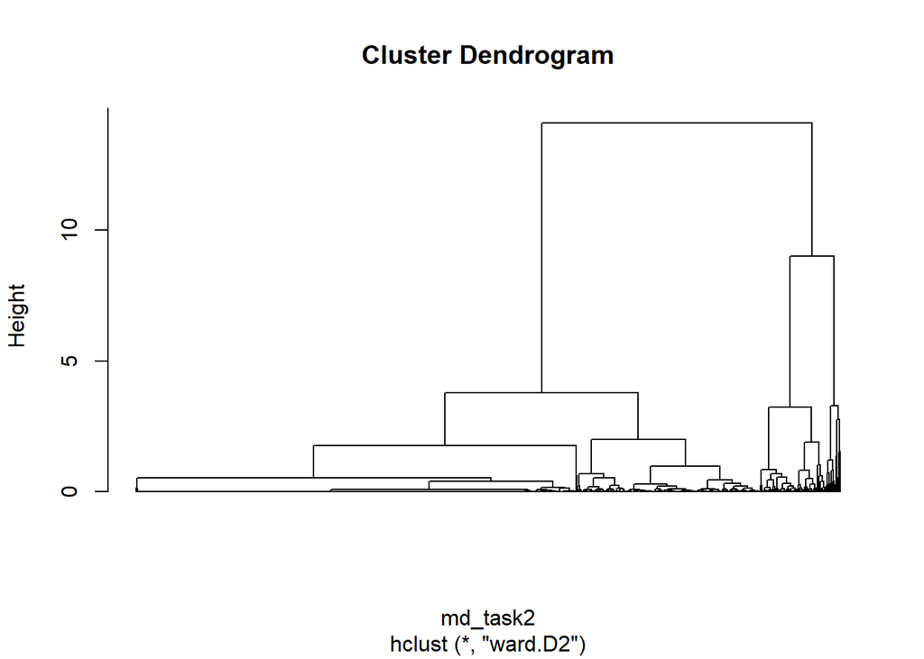

```r
clusters_task2 <- hclust (md_task2, method = "ward.D2")
plot(clusters_task2, labels = F, hang = -1)
```

Покрасим дендрограмму:

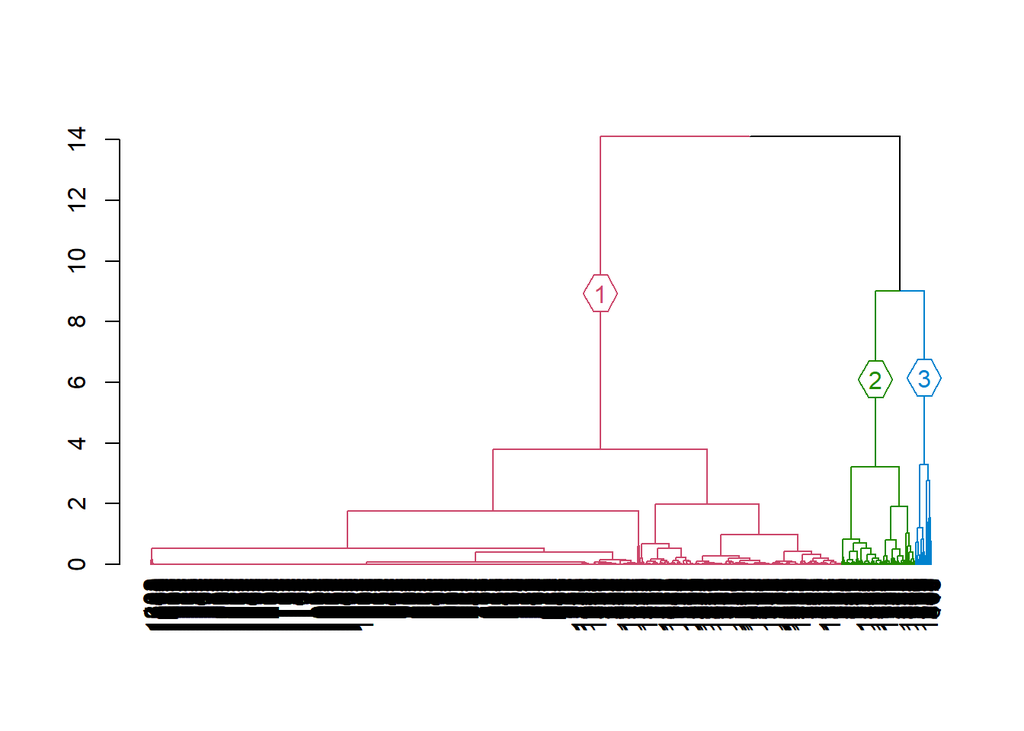

```r
dendr_task2 <- as.dendrogram(clusters_task2)
col_dendr_task2 <- color_branches(dendr_task2, k = 3, groupLabels = T)
plot(col_dendr_task2)
```

Похоже, что кластеров должно быть 2 или 3

Проверим методом локтя:

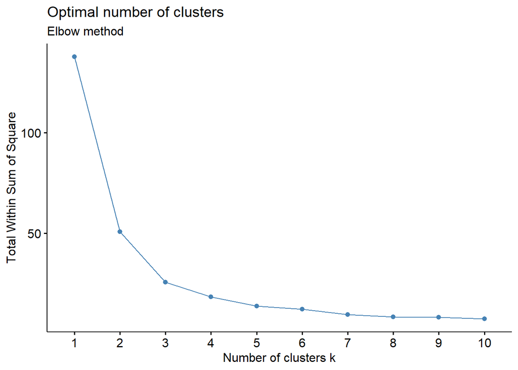

```r
fviz_nbclust(task2, kmeans, method = "wss")+
  labs(subtitle = "Elbow method")
```

Присвоим наблюдениям номера кластеров:

```r
groups2_task2 <- cutree(clusters_task2, k = 2)
task2$groups2 <- factor(cutree(clusters_task2, k = 2))
```

Описательные статистики по кластерам, содержание

```r
task2 %>% filter(groups2_task2 == 1) %>% skim
task2 %>% filter(groups2_task2 == 2) %>% skim
```

Группа 1: N=1280, mean PUBL=-0.17 mean CIT=-0.06

Группа 2: N=165, mean PUBL=0.57 mean CIT=0.039

Визуализируем 2 кластера:

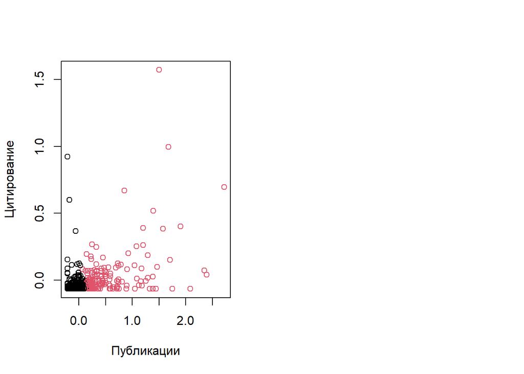

```r
clusterplot_task2 <- par(mfrow = c(1, 2))
plot(task2[c("st_WOSPUBL", "st_WOSCIT")], col=task2$groups2, xlab="Публикации", ylab = "Цитирование")
points(clusters_task2$centers[,c("st_WOSPUBL", "st_WOSCIT")], col=4:6, pch=20, cex=2)
```

Визуализируем 3 кластера:

```r
groups3_task2 <- cutree(clusters_task2, k = 3)
task2$groups3 <- factor(cutree(clusters_task2, k = 3))
clusters_task2_k <- kmeans(task2, 3)
```

[output not shown]

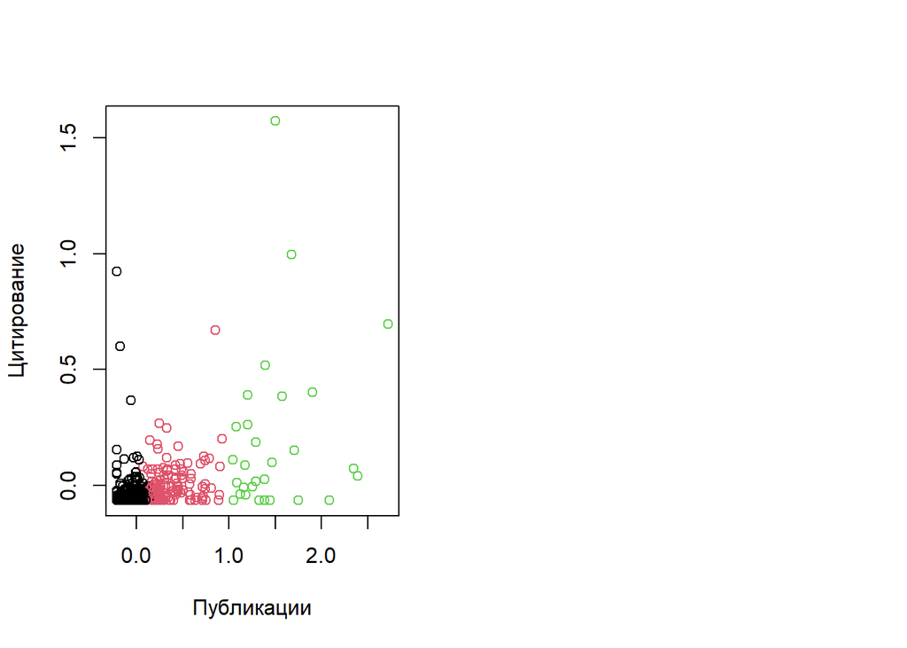

```r
clusterplot_task2 <- par(mfrow = c(1, 2))
plot(task2[c("st_WOSPUBL", "st_WOSCIT")], col=task2$groups3, xlab="Публикации", ylab = "Цитирование") +
points(clusters_task2$centers[,c("st_WOSPUBL", "st_WOSCIT")], col=7:9, pch=20, cex=2)
```

Описательные статистики по 3 кластерам, содержание

```r
task2 %>% filter(groups3 == 1) %>% skim # N=1280, mean PUBL=-0.17 mean CIT=-0.06
task2 %>% filter(groups3 == 2) %>% skim # N=136,  mean PUBL=0.378 mean CIT=0.00
task2 %>% filter(groups3 == 3) %>% skim # N=29,  mean PUBL=1.49 mean CIT=0.20
```

Группа 1 не изменилась. Группа 2 разделилась на две.

Вычислим соотношения CIT и PUBL в кластерах 1 и 2:

Группа 1: -0.06/-0.17 = 0.35

Группа 2: 0.004/0.378 = 0.01

**ВЫВОД:** В целом можно признать группу 1 “эффективнее” по КПД, чем группа 2, потому что при меньшем кол-ве публикаций в WoS цитируемость здесь примерно та же. В малочисленной группе 3 больше пишут и их больше цитируют